# Maine Transportation Data

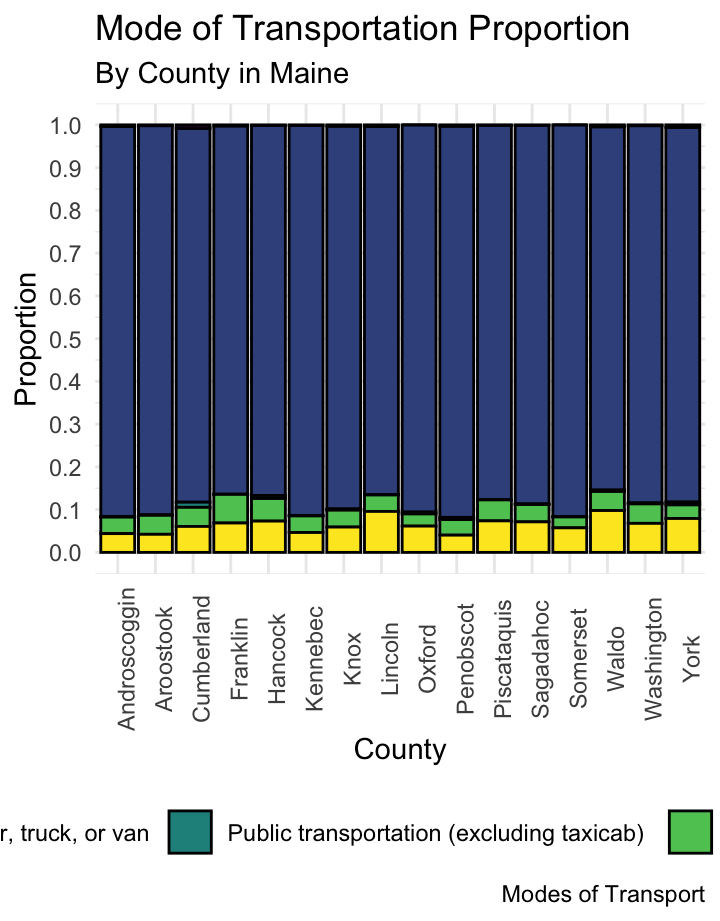

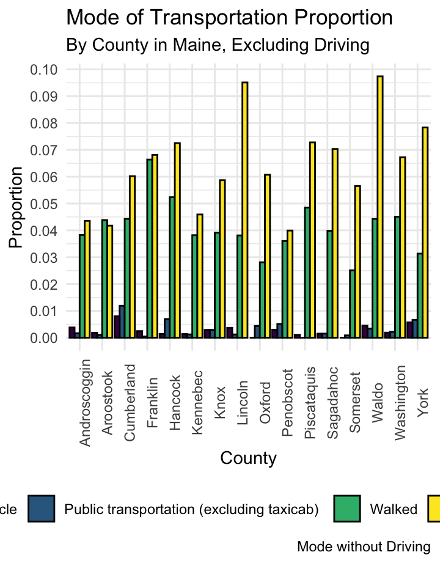

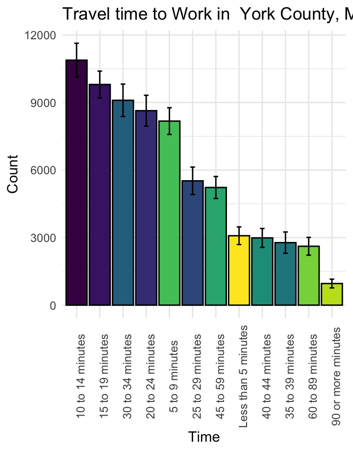

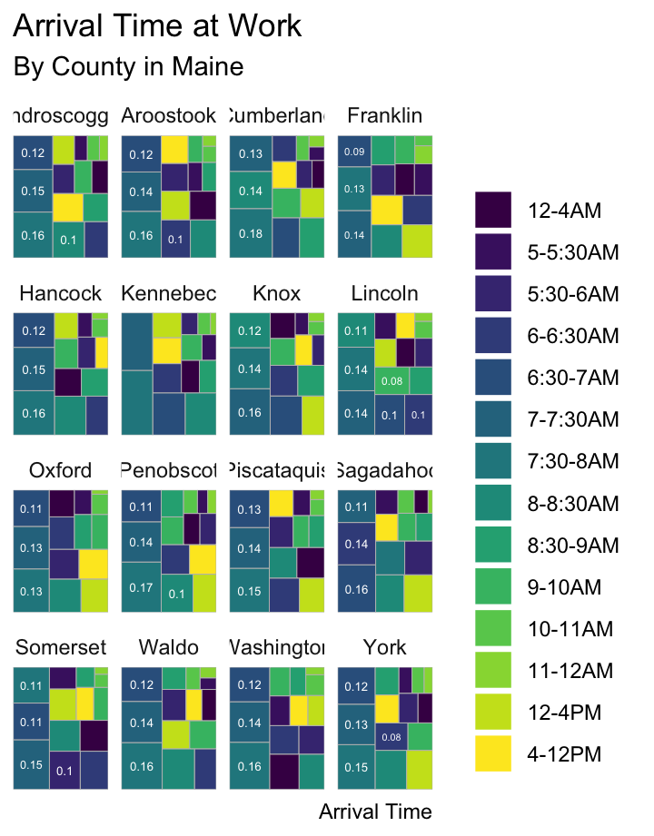

# About

**What is the purpose of this dashboard?**

This dashboard allows for the exploration of transportation data in Maine counties. The data come from the 2017 American Community Survey on the county level and can be obtained using the [tidycensus API](https://walker-data.com/tidycensus/).

# Data

The data used in this dashboard is from the [2017 American Community Survey](https://www.census.gov/programs-surveys/acs) and were obtained using the [tidycensus API](https://walker-data.com/tidycensus/).

*The American Community Survey (ACS) helps local officials, community leaders, and businesses understand the changes taking place in their communities. It is the premier source for detailed population and housing information about our nation.*

[interactive table not shown]

# Static 1

# Static 2

# Interactive 1

# Interactive 2

# Analysis

I grew up in Maine, so I choose to analyze data from Maine on the county level. First, I browse possible variables from the ACS 2017 survey on the county level. I decide to investigate travel time to work for workplace geography, means of transportation to work for workplace geography, and time arriving at work from home for workplace geography.

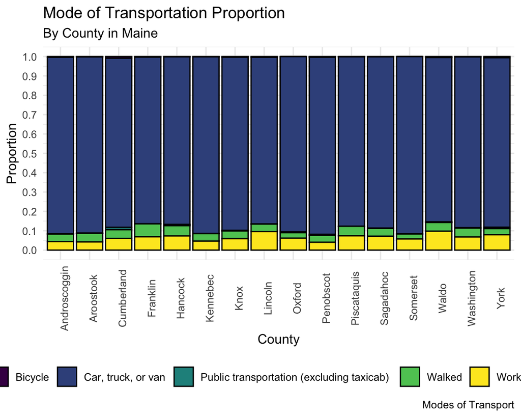

We see that the vast majority of people across all counties drive to work. Let’s look at all modes of transport besides driving.

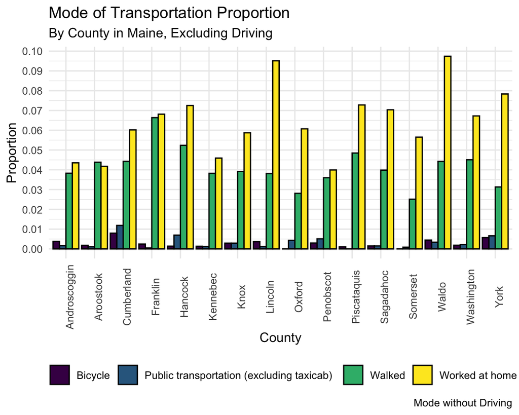

Conclusion: driving dominates travel to work for all counties in Maine. Working from home is most common in Lincoln and Waldo counties, walking is most common Franklin and Hancock counties, and biking is most common in Cumberland and York counties.

### Travel Times

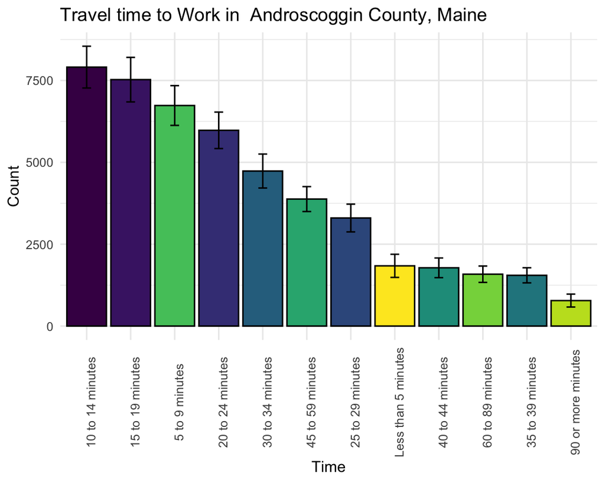

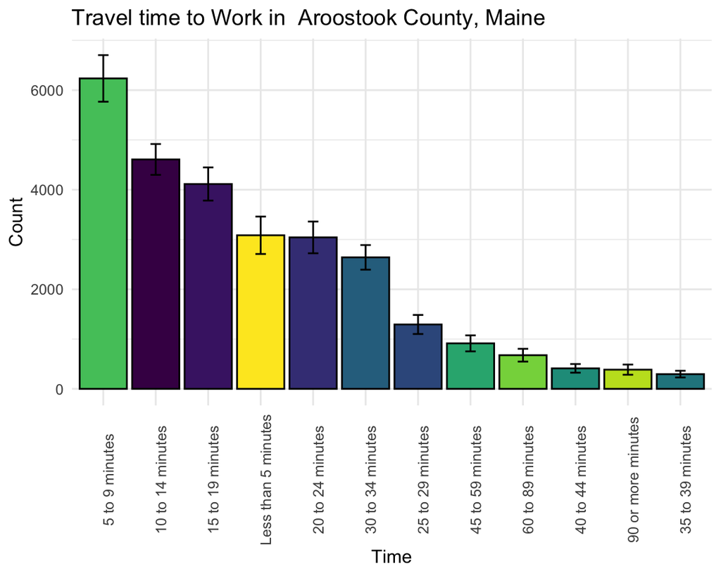

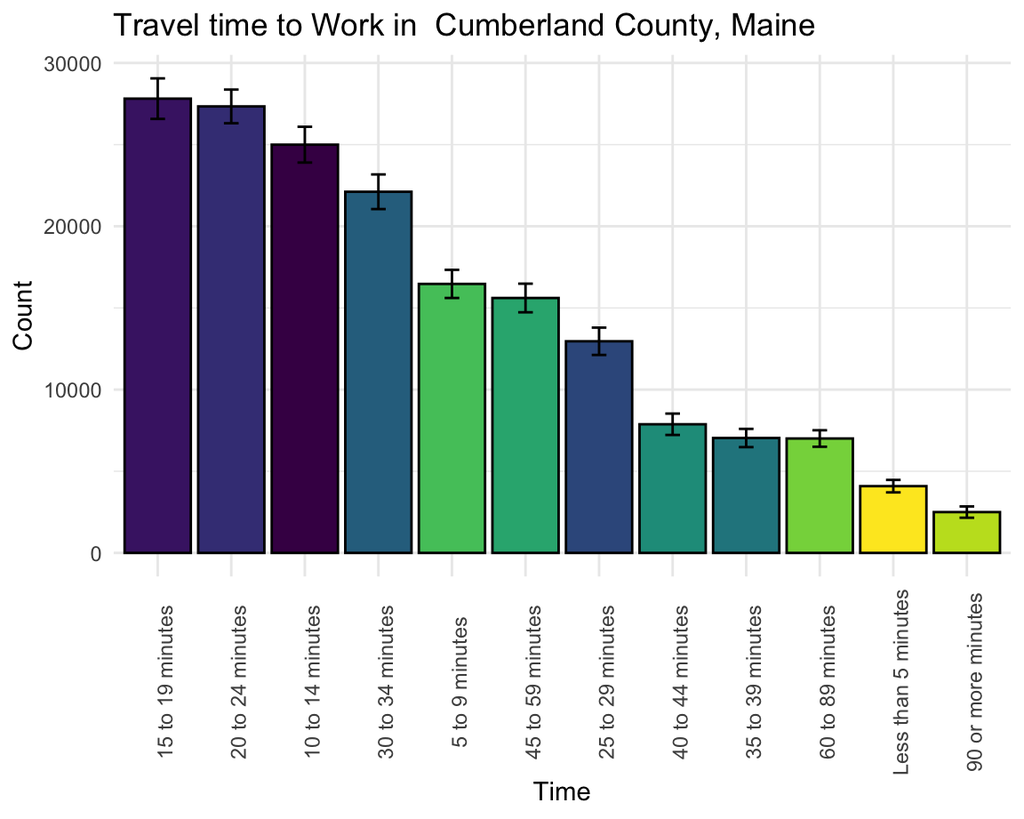

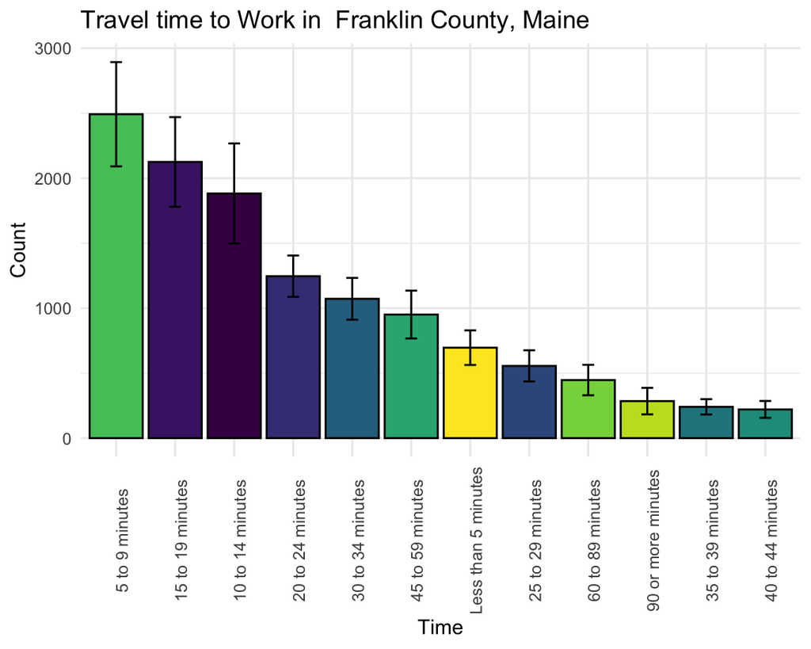

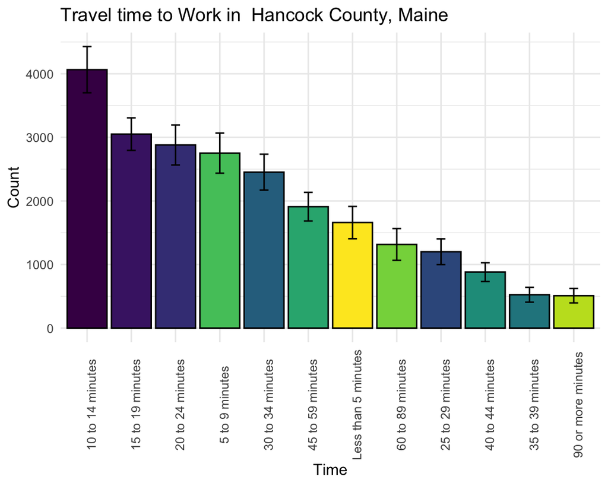

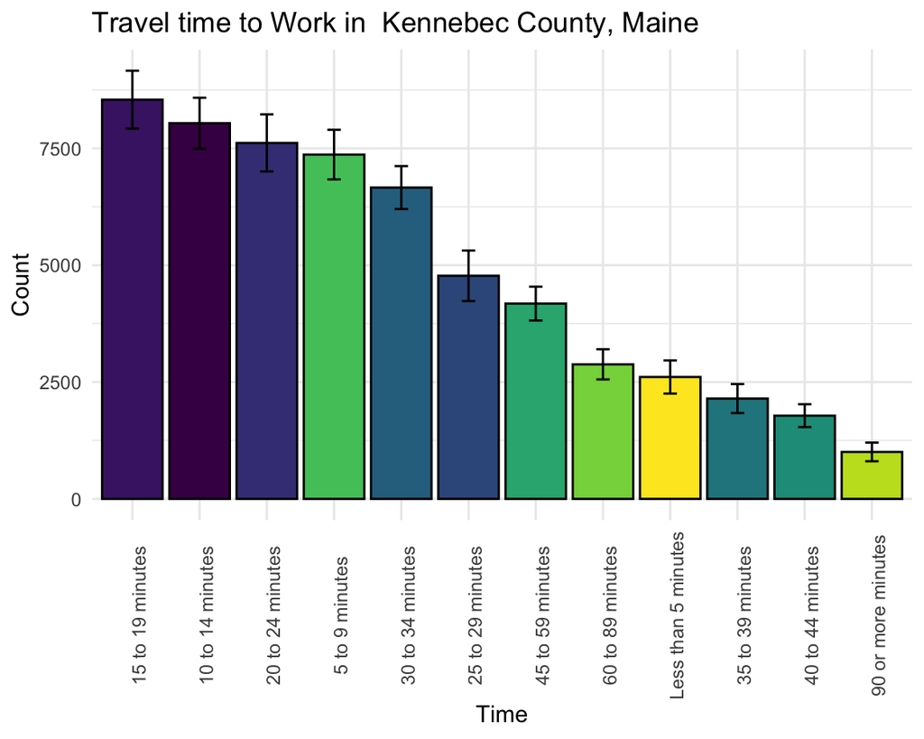

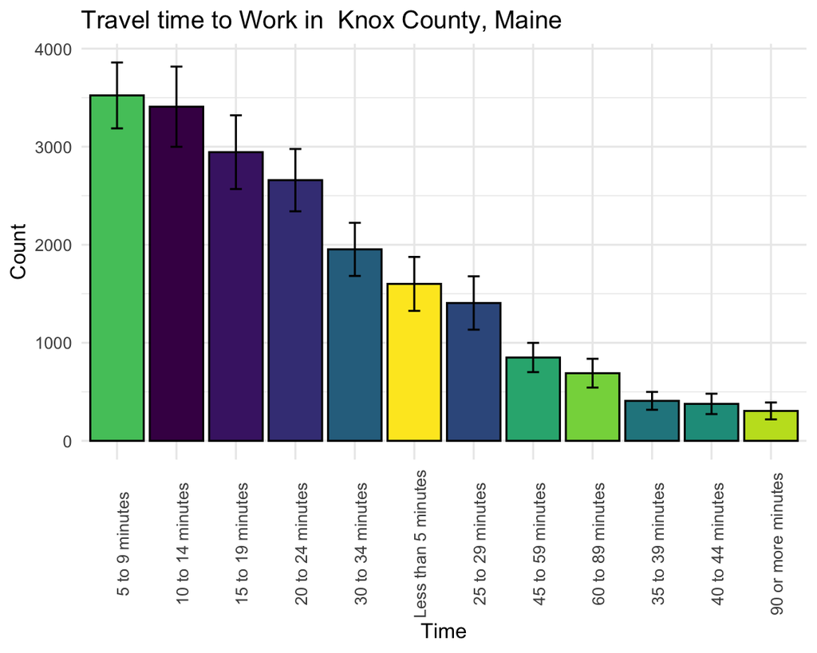

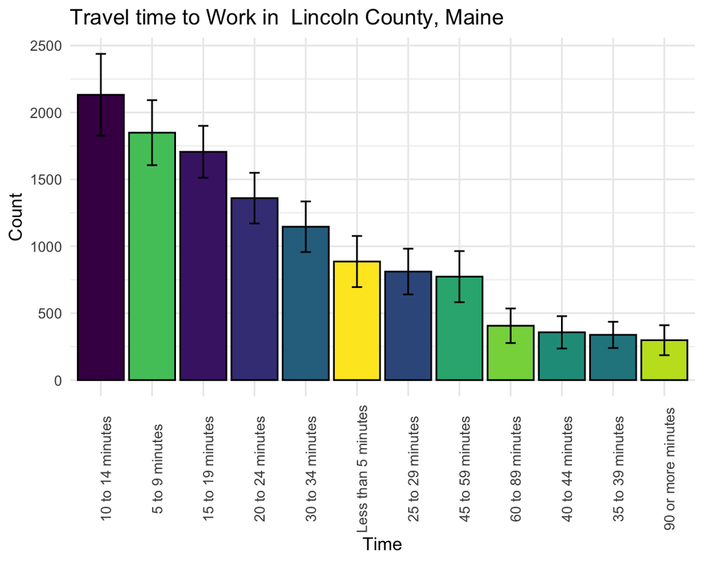

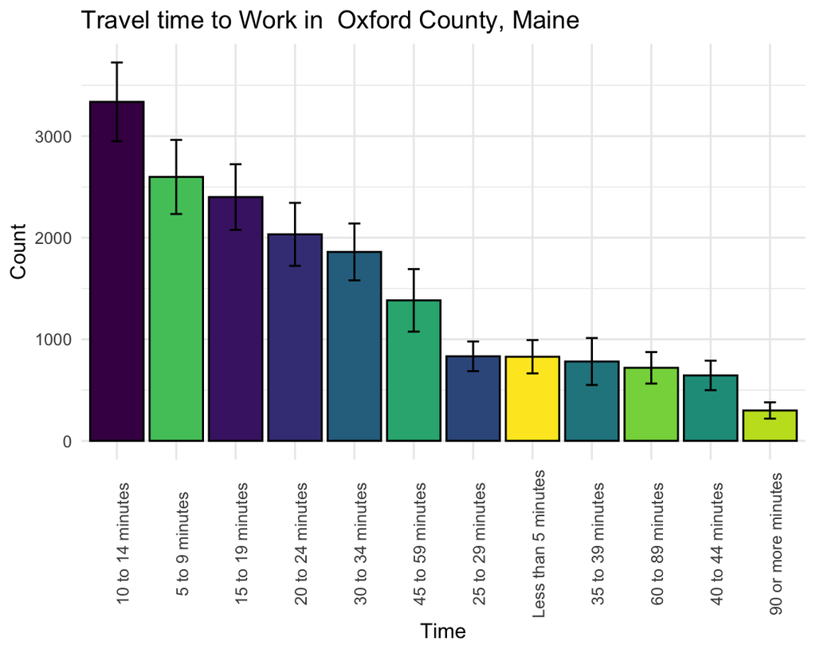

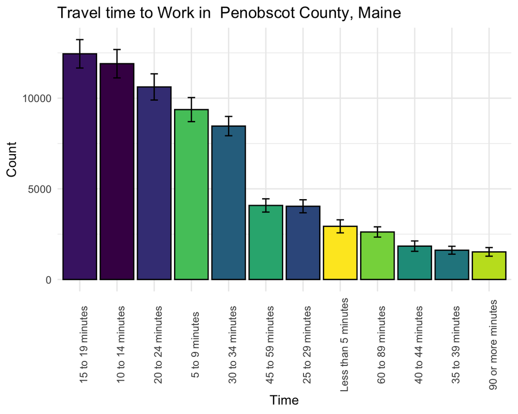

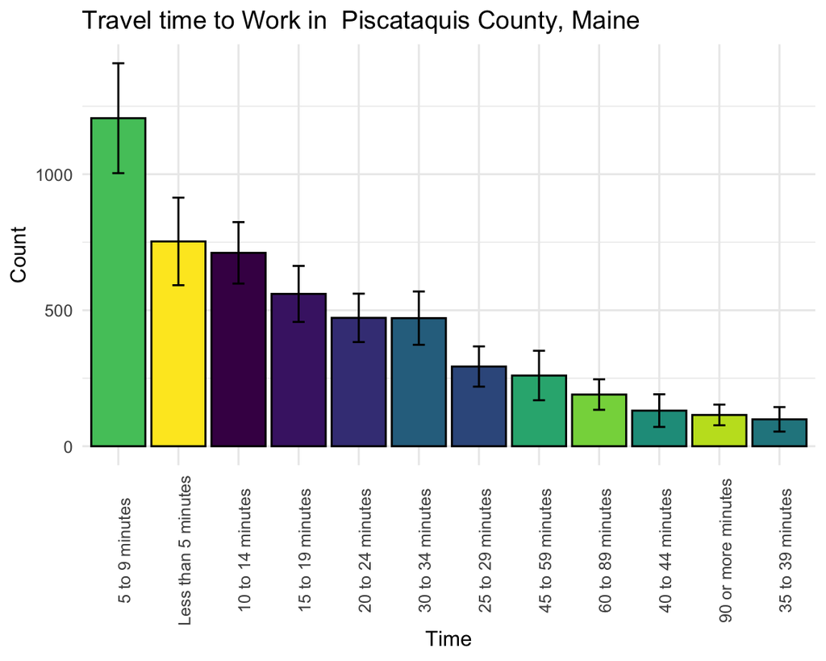

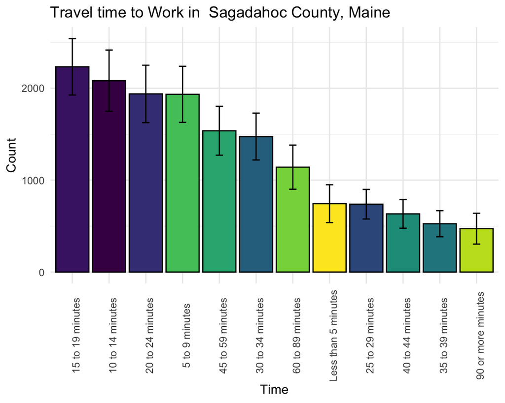

[4 more figures not shown]

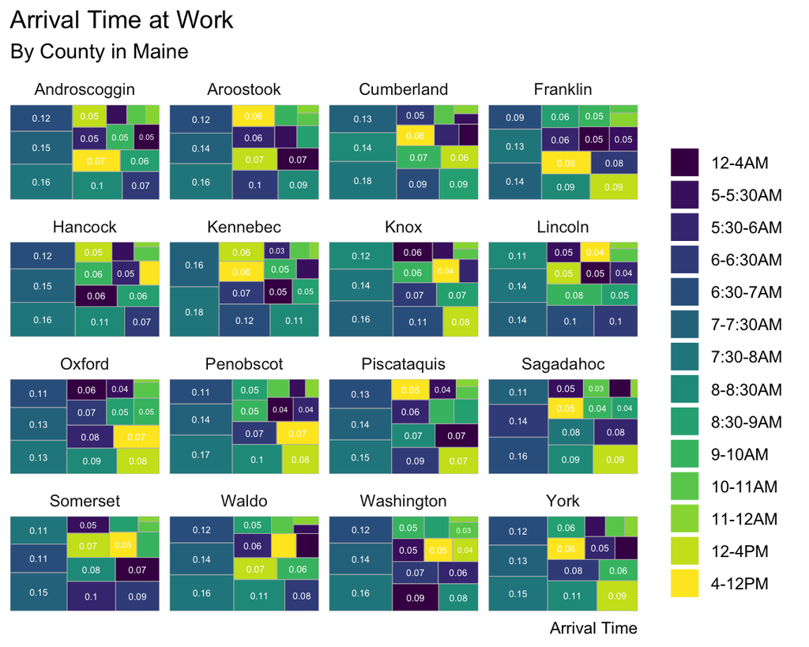